# Data wrangling: Extension Exercises

Ben Whalley

September 2020

# More on Long vs wide data

## Further reading

**#1**

To gain more understanding of the way the format of our data is important to the way we analyse it, read this article on wide/long data formats and the tradeoffs between the two: https://www.theanalysisfactor.com/wide-and-long-data/

## Separating ‘untidy’ variables into tidy, long-form data:

```r
N <- 20
repeatmeasuresdata <- tibble(person = 1:N,
  time_1 = rnorm(N),
  time_2 = rnorm(N, 1),
  time_3 = rnorm(N, 3))

repeatmeasuresdata %>% head
> # A tibble: 6 x 4
>   person time_1 time_2 time_3
>    <int>  <dbl>  <dbl>  <dbl>
> 1      1 -0.761  0.191   2.48
> 2      2  0.892  0.871   2.71
> 3      3  1.42   1.32    3.80
> 4      4  0.847  1.92    3.48
> 5      5 -1.26   0.997   2.66
> 6      6  0.379  0.412   3.76
```

`repeatmeasuresdata` is in **wide** format. Each row contains data for one participant, and each participant has three observations.

We can melt or reshape the data into longer format like so:

```r
repeatmeasuresdata %>%
  pivot_longer(starts_with("time")) %>%
  arrange(person, name) %>%
  head(8)
> # A tibble: 8 x 3
>   person name    value
>    <int> <chr>   <dbl>
> 1      1 time_1 -0.761
> 2      1 time_2  0.191
> 3      1 time_3  2.48
> 4      2 time_1  0.892
> 5      2 time_2  0.871
> 6      2 time_3  2.71
> 7      3 time_1  1.42
> 8      3 time_2  1.32
```

The problem we have now is that `name` contains text which describes at which time the observation was made. We probably want a number for each timepoint, so we can make a plot with time on the x axis.

The `separate` command separates a single character column (`name`) into multiple columns. Rather than have a column with labels of the form ‘time_1’, it can create two columns, with labels ‘time’ and ‘1’ in each.

```r
longrepeatmeasuresdata <- repeatmeasuresdata %>%
  pivot_longer(starts_with("time")) %>%
  separate(name, into = c("variable", "time"))

longrepeatmeasuresdata %>% head
> # A tibble: 6 x 4
>   person variable time   value
>    <int> <chr>    <chr>  <dbl>
> 1      1 time     1     -0.761
> 2      1 time     2      0.191
> 3      1 time     3      2.48
> 4      2 time     1      0.892
> 5      2 time     2      0.871
> 6      2 time     3      2.71
```

Now the data are in long format, we can plot the points over time:

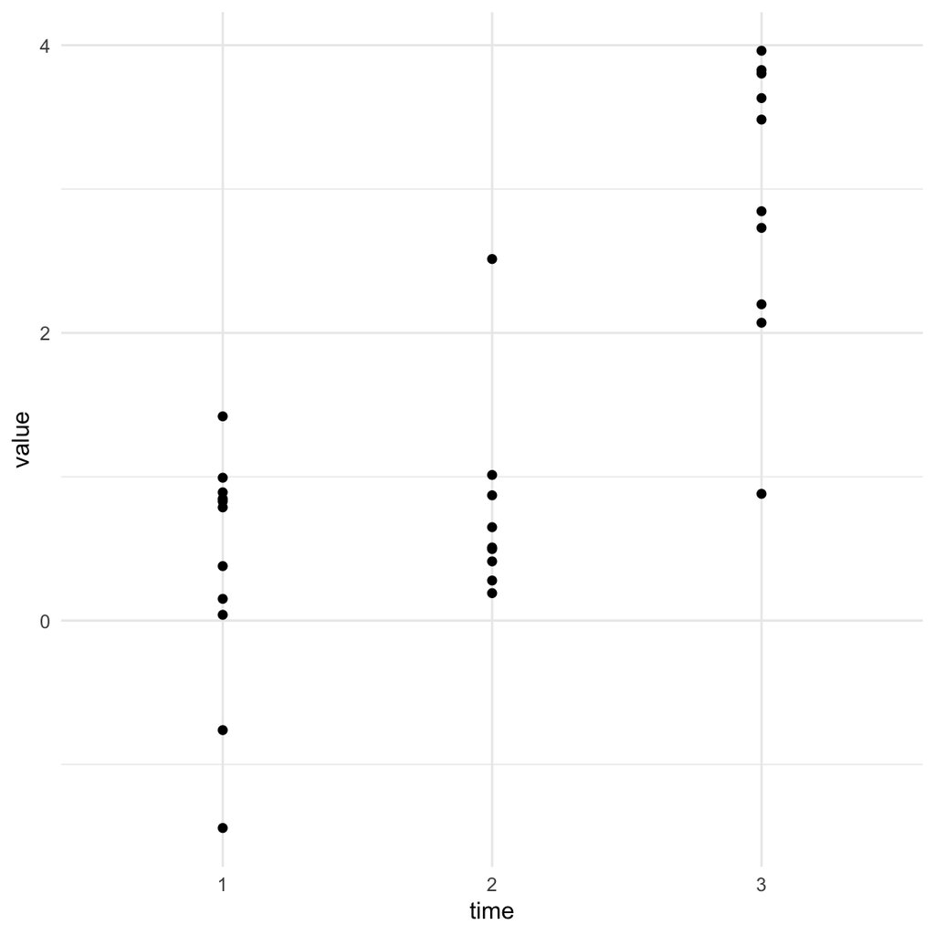

```r
longrepeatmeasuresdata %>%
  sample_n(30) %>%
  ggplot(aes(x=time, y=value)) +
  geom_point()
```

**#2**

This file contains sample contact and address data for 100 people: https://letterhub.com/wp-content/uploads/2018/03/100-contacts.csv

- Read the data into R
- Use the `separate` function to make a new variable which contains the *domain name* of these contacts’ email address (e.g. yahoo.com, hotmail.com)

Use the `distinct` and/or `count` functions on the new variable you create containing the domain name. Look them up in the help file if you don’t know which to use to answer these questions:

- How many different domains do the contacts have addresses with?
- How many people had a gmail account?
- Which domains had more than 10 users?

```r
contacts <- read_csv('https://letterhub.com/wp-content/uploads/2018/03/100-contacts.csv') %>%
  separate(email, into=c("user", "domain"), sep ="@")


# how many different domains
contacts %>%
  distinct(domain) %>%
  count()
> # A tibble: 1 x 1
>       n
>   <int>
> 1    39

# how many people use gmail
contacts %>%
  count(domain) %>%
  filter(domain=="gmail.com")
> # A tibble: 1 x 2
>   domain        n
>   <chr>     <int>
> 1 gmail.com    16

# which domains had more than 10 users?
contacts %>%
  count(domain) %>%
  filter(n > 10)
> # A tibble: 4 x 2
>   domain          n
>   <chr>       <int>
> 1 aol.com        13
> 2 gmail.com      16
> 3 hotmail.com    13
> 4 yahoo.com      13
```

# More `pivot_longer` and plotting

**#3**

Use the `mtcars` data and facetting to produce these plots:

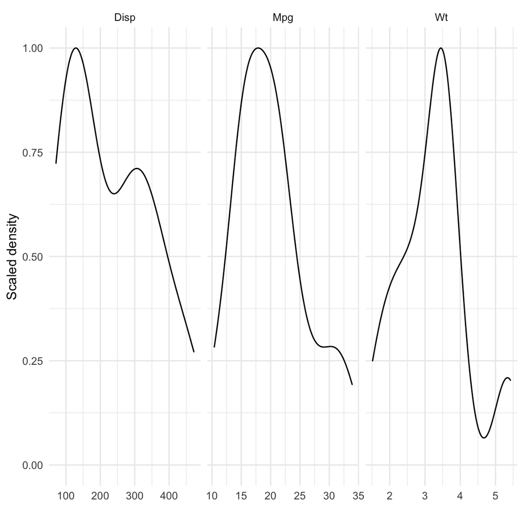

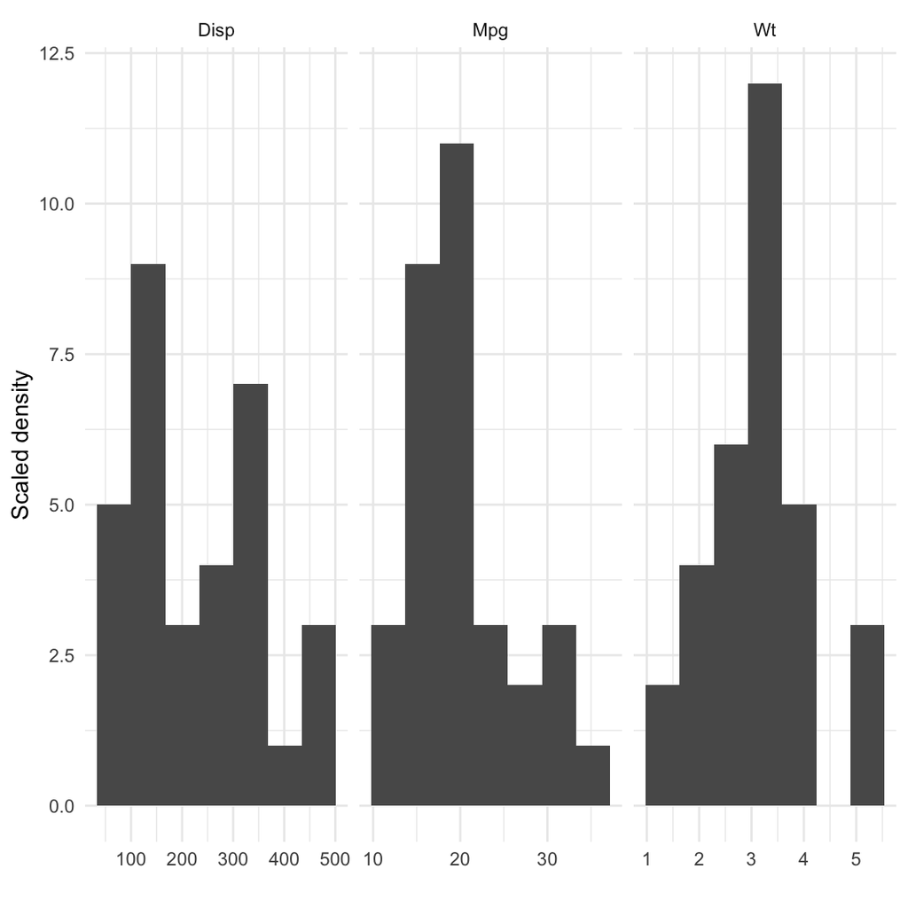

Some tips:

- Add `scales="free_x"` to the `facet_wrap` function. So, it will read: `facet_wrap(~VARNAME, scales="free_x")`
- For the histogram, replace `geom_density()` with `geom_histogram()`
- Adjust the number of vertical bars in the histogram by adding `bins=7` (or some other number) to `geom_histogram()`

# More practice

For more practice using these techniques for common problems in psychological research you could work through Andy Will’s ‘better tables’ worksheet here:

- https://ajwills72.github.io/rminr/better-tables.html
- [Preprocessing data from experiments](https://ajwills72.github.io/rminr/preproc.html) and [part 2 of this](https://ajwills72.github.io/rminr/more-on-preproc.html)

All content on this site distributed under a [Creative Commons](https://creativecommons.org/) licence. CC-BY-SA 4.0.